Ficha del establecimiento

# Inst. Reg. Educ Adultos San Miguel

RBD **9460**San MiguelEscuela o liceo

185estudiantes matriculadosCorte Agosto 2026

Mujeres37,8%70 est.

Hombres62,2%115 est.

Chilenos/as82,7%153 est.

Extranjeros/as17,3%32 est.

Actualizada al 05-10-2026

💻Ver ficha completaVersión para computador, con mapas y gráficos interactivos. Pesa varios MB: mejor ábrela con wifi.

🏛️Identificación

## Identificación del establecimiento

Los datos de contacto y las características básicas del establecimiento, tal como están registrados en el Ministerio de Educación. **Si algo está mal o falta, escríbenos** y lo corregimos en la próxima actualización.

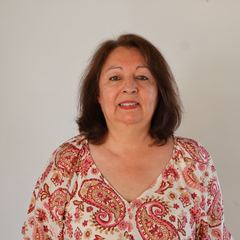

Director o directora

Grecia Del Carmen Opazo Leon

**Nombre**

Inst. Reg. Educ Adultos San Miguel

**RBD**

9460

**Dirección**

San Ignacio 4010

**Comuna**

San Miguel

**Tipo**

Escuela o liceo

**Estado**

✅En funcionamiento

**Director/a**

Grecia Del Carmen Opazo Leon

**Correo**

ireasanmiguel@slepsantarosa.cl

**Teléfono**

43144698

**Sitio web**

WWW.IREA.CMSM.CL

**Matrícula**

GRATUITO

**Sostenedor**

El sostenedor corresponde a una persona jurídica

**Orientación**

Orientación religiosa Laica

### Niveles que imparte

✓ 📖 Media Humanístico-Científica Adultos

### Vulnerabilidad del alumnado

Índice de vulnerabilidad (IVE)

—

Lo calcula JUNAEB y sirve para asignar programas de apoyo.

**Un IVE más alto significa más necesidad de apoyo**, no peor calidad. Se usa para decidir a qué establecimientos llegan primero los programas de alimentación, salud y becas.

### Apoyos profesionales al aprendizaje

✓ 📚 Reforzamiento✓ 🧠 Psicólogo/a✓ 🧭 Orientador/a✓ 👩‍🏫 Profesor/a de educación especial✓ 🤝 Asistente social🧩 Psicopedagogo/a🎓 Orientación vocacional🗣️ Fonoaudiólogo/a➕ Otro

### Infraestructura y atención a la diversidad

✓ 📚 Biblioteca✓ 🏛️ Sala multiuso✓ 🌐 Computadores con internet✓ 🖥️ Sala de informática🔬 Laboratorio💻 Computadores📽️ Sala audiovisual🏟️ Cancha deportiva🤾 Gimnasio♿ Accesibilidad NEE➕ Otra

✓ 👁️ Discapacidad visual✓ 👂 Discapacidad auditiva✓ 🧠 Discapacidad intelectual✓ 🧩 Trastorno del espectro autista✓ 📖 Dificultades de aprendizaje✓ 🎯 Déficit atencional🦽 Discapacidad motora💬 Trastornos de la comunicación🗣️ Trastorno específico del lenguaje📊 Funcionamiento intelectual limítrofe

Las etiquetas con ✓ son las que el establecimiento declaró en el directorio oficial; las grises no están marcadas.

### Jornada Escolar Completa (JEC)

Cursos con jornada completa

0

Cursos sin jornada completa

**Ver curso por curso**

| Grado | Cursos | Jornada |
| --- | --- | --- |
| 1° Nivel (Adultos) | 2 | — Sin JEC |
| 2° Nivel (Adultos) | 4 | — Sin JEC |

Con **Jornada Escolar Completa** los estudiantes tienen más horas de clases al día y almuerzan en el establecimiento.

### Idiomas

**Inglés en Enseñanza Media**

Intermedio

### Certificación ambiental (SNCAE)

El establecimiento no tiene certificación del Sistema Nacional de Certificación Ambiental de Establecimientos Educacionales (SNCAE).

### Concentración de alumnado prioritario

Concentración 2026

44,8%

▲16,36 pts

Porcentaje de estudiantes prioritarios reconocidos por el Mineduc.

0%100%

Concentración del establecimiento

Concentración 2025

28,5%

Resolución exenta

2026

Observación del Ministerio: **Sin ACAP 2025-2026**.

La **concentración de prioritarios** define cuánta Subvención Escolar Preferencial (SEP) recibe el establecimiento. Sobre 60 % da acceso a la asignación por concentración.

### Requisitos para postular

✓ 🎂 Cumplir la edad mínima✓ 📄 Certificado de nacimiento✓ 📊 Certificado de notas✓ ⚖️ Firmar el reglamento de convivencia✓ ➕ Otro: INFORME SOCIO ECONÓMICO📝 Informe de personalidad🏠 Ficha de protección social🧪 Test de intereses♿ Informe de necesidades educativas✍️ Firmar el proyecto educativo📋 Examen de ingreso👥 Entrevista con apoderados🎲 Sorteo💍 Certificado de matrimonio⛪ Certificado de bautismo⛪ Certificado de matrimonio religioso💰 Pago de postulación

Desde el Sistema de Admisión Escolar, los establecimientos públicos **no pueden seleccionar** por rendimiento ni por antecedentes socioeconómicos. Estos son los antecedentes administrativos que el establecimiento declara pedir.

**Equipo del SLEP que acompaña al establecimiento**

**Asesor/a territorial**

RUBÉN CORTEZ GALLARDO

**Correo UTP**

utp.ireasanmiguel@slepsantarosa.cl

**Correo Inspectoría**

inspectoria.ireasanmiguel@slepsantarosa.cl

🏫Matrícula

## Matrícula y asistencia

Cuántos estudiantes tiene el establecimiento, quiénes son y cuántos días van efectivamente a clases. **La asistencia es el porcentaje de días que los estudiantes asistieron** sobre los días en que estuvieron matriculados.

Matrícula · Agosto 2026

185

▲30,3%

Variación desde el primer mes del año escolar.

1141.024

Este establecimientoPromedio del SLEP 333

Asistencia promedio

52,7%

Días asistidos sobre días matriculados.

-7,1%95,6%

Este añoPromedio de años anteriores 29,5%

Cursos

6

Niveles

1

Matrícula regular

0

Estudiantes en la modalidad regular del establecimiento.

Matrícula no regular

185

Modalidades de adultos, reingreso o validación de estudios.

Matrícula mes a mes · 2026

Cuántos estudiantes había registrados al cierre de cada mes.

Asistencia mes a mes · 2026

Porcentaje de días asistidos sobre los días en que el estudiante estuvo matriculado.

Matrícula año a año

Matrícula del último mes de cada año escolar.

### Quiénes estudian acá

Por género

Hombres · 115Mujeres · 70

Por origen

Chilenos/as · 153Extranjeros/as · 32Nacionalizados/as · 0

Nacionalidades presentes

Número de estudiantes por país de nacimiento declarado.

🇨🇴 Colombiana6

🇻🇪 Venezolana4

🇨🇺 Cubana1

🌐 Otra1

❔ Sin información1

Pueblos originarios

Estudiantes que declaran pertenecer a un pueblo originario.

🌿 Mapuche4

### Por nivel de enseñanza

Matrícula por nivel

📖 Media Humanístico-Científica Adultos185

Asistencia por nivel

La escala va de 0 % a 100 %.

📖 Media Humanístico-Científica Adultos52,7%

### Asistencia por grupo

Asistencia por género

Promedio ponderado por el número de estudiantes de cada grupo.

Hombres52,3%

Mujeres53,3%

Asistencia por origen

Chilenos/as53,4%

Extranjeros/as49,1%

Asistencia por nacionalidad

Solo los seis grupos con más estudiantes.

🇨🇱 Chilena53,4%

🇨🇴 Colombiana46,8%

🇻🇪 Venezolana38,1%

🇨🇺 Cubana100,0%

🌐 Otra19,0%

❔ Sin información19,0%

Asistencia por pueblo originario

🌿 Mapuche36,0%

**Ver el detalle curso por curso (6 cursos)**

| Curso | Matrícula | Asistencia % |
| --- | --- | --- |
| 1° Nivel (Adultos) A | 31 | 56,1 |
| 1° Nivel (Adultos) B | 34 | 49,2 |
| 2° Nivel (Adultos) A | 26 | 55,2 |
| 2° Nivel (Adultos) B | 24 | 38,1 |
| 2° Nivel (Adultos) C | 35 | 54,6 |
| 2° Nivel (Adultos) D | 35 | 59,1 |

**Ver la matrícula año a año, con su variación**

| Periodo | Matrícula | Variación | Cambio |
| --- | --- | --- | --- |
| 2026 | 185 | +25,0 | +15,6% |
| 2025 | 160 | −1,0 | −0,6% |
| 2024 | 161 | −12,0 | −6,9% |
| 2023 | 173 | −2,0 | −1,1% |
| 2022 | 175 | −57,0 | −24,6% |
| 2019 | 232 | −4,0 | −1,7% |
| 2018 | 236 | +13,0 | +5,8% |
| 2017 | 223 | +25,0 | +12,6% |
| 2016 | 198 | — | — |

**Ver la asistencia año a año, con su variación**

| Periodo | Asistencia | Variación | Cambio |
| --- | --- | --- | --- |
| 2026 | 52,7% | — | — |
| 2025 | — | — | — |
| 2024 | 0,0% | — | — |
| 2023 | — | — | — |
| 2022 | — | — | — |
| 2019 | 0,0% | — | — |
| 2018 | — | — | — |
| 2017 | — | — | — |
| 2016 | 88,5% | — | — |

La matrícula se cuenta al cierre de cada mes, así que los cambios durante el año reflejan traslados y retiros. Corte usado: **Agosto 2026**.

🤝Vida escolar

## Vida escolar y comunidad

Qué actividades ofrece el establecimiento fuera de las clases, cómo se organiza con las familias y quiénes representan a la comunidad. **Las etiquetas con ✓ son las que el establecimiento declaró** en el directorio oficial del Ministerio; las grises no están marcadas.

### Talleres y actividades para estudiantes

✓ ➕ Otra: DESARROLLO DE COMPETENCIAS SOCIO AFECTIVAS🧭 Orientación🤝 Convivencia🚫 Prevención drogas❤️ Educación sexual🌱 Medio ambiente🌟 Vida sana🫂 Acción social✝️ Pastoral

Actividades de formación: orientación, convivencia, prevención y vida sana.

El establecimiento no registra ninguna de estas actividades en el directorio oficial.

Talleres de arte, cultura y tecnología fuera del horario de clases.

✓ 🏓 Tenis de mesa⚽ Fútbol🥅 Baby fútbol🏃 Atletismo🏐 Vóleibol🏀 Básquetbol🏊 Natación🤸 Gimnasia🎾 Tenis♟️ Ajedrez➕ Otro

Disciplinas deportivas que ofrece el establecimiento.

### Trabajo con las familias

✓ 👪 Talleres de formación🎉 Actividades de integración📈 Perfeccionamiento➕ Otra

✓ 📒 Libreta de comunicaciones✓ 🌐 Web y redes sociales✓ 🗣️ Consejo escolar✓ 📄 Reuniones generales✓ ➕ Otro: PLATAFORMA GOOGLE (MAIL, DOCS, CALENDAR)👥 Entrevistas individuales

Por dónde el establecimiento se comunica con apoderados y apoderadas.

### Organizaciones de la comunidad

**Centro de Padres**

Constituido

**Personalidad jurídica**

No aplica

**Última elección de directiva**

No aplica

**Centro de Estudiantes**

Constituido

**Representante del sostenedor en el Consejo Escolar**

Solange Oñate Castillo

**Acompañamiento del Consejo Escolar**

Solange Oñate Castillo

Para contactar al centro de padres o al centro de estudiantes, escribe al establecimiento: sus datos están más arriba.

El **Consejo Escolar** es la instancia donde se juntan dirección, docentes, asistentes, apoderados y estudiantes para conversar sobre la marcha del establecimiento.

### Normativa y conectividad

**Uso de uniforme**

No se usa uniforme

**Tipo de conexión**

ADSL o cable coaxial

**Velocidad de internet**

Sin información

🧭Gestión

## Instrumentos de gestión: PEI y PME

El **PEI** dice quién quiere ser el establecimiento: su misión, su visión y sus sellos. El **PME** dice qué va a hacer este año para lograrlo, con responsables y presupuesto. Son los dos documentos que ordenan el trabajo.

### Proyecto Educativo Institucional (PEI)

**Misión**

Somos una comunidad escolar abierta a la diversidad, que apoya la permanencia en el sistema educativo de personas jóvenes y adultas, en la que los estudiantes son sujetos activos en la construcción de su aprendizaje y se valora la participación, la democracia, colaboración, el cuidado del Medio Ambiente, y desarrollo de habilidades de autocuidado

**Visión**

El Instituto Regional de Educación de Adultos será reconocido como un espacio educativo dialogante e inclusivo, en el que jóvenes y adultos mediante el desarrollo de conocimientos, habilidades y actitudes se forman integralmente al interior de una comunidad que aprende y trabaja colaborativamente

### Énfasis declarados, en orden de prioridad

**1º**

Inclusivo

**2º**

Desarrollo integral

**3º**

Inserción laboral

### Documentos oficiales

[📘Proyecto Educativo](https://wwwfs.mineduc.cl/Archivos/infoescuelas/documentos/9460/ProyectoEducativo9460.pdf)[⚖️Reglamento de Convivencia](https://wwwfs.mineduc.cl/Archivos/infoescuelas/documentos/9460/ReglamentodeConvivencia9460.pdf)[📊Reglamento de Evaluación](https://wwwfs.mineduc.cl/Archivos/infoescuelas/documentos/9460/ReglamentoDeEvaluacion9460.pdf)

### Plan de Mejoramiento Educativo (PME)

📭**No hay acciones PME registradas para este año.**El PME se carga una vez al año desde la plataforma del Ministerio.

🏆SNED

## SNED · Sistema Nacional de Evaluación del Desempeño

El SNED evalúa cada dos años el desempeño de los establecimientos municipales y particulares subvencionados. Mira **seis factores**: efectividad, superación, igualdad de oportunidades, iniciativa, integración y mejoramiento.

⚪No seleccionado

Índice SNED del establecimiento

Va de 0 a 100 y resume los seis factores que evalúa el sistema.

Los seis factores, uno por uno

Cada factor va de 0 a 100. Los de arriba pesan más en el índice final.

Efectividad46,6%

Superación49,0%

Igualdad de oportunidades96,8%

Iniciativa86,9%

Integración55,8%

Mejoramiento100,0%

**¿Cuánto pesa cada factor?**

| Factor | Puntaje | Peso en el índice (%) |
| --- | --- | --- |
| Efectividad | 46,6 | 37 |
| Superación | 49 | 28 |
| Igualdad de oportunidades | 96,8 | 22 |
| Iniciativa | 86,9 | 6 |
| Integración | 55,8 | 5 |
| Mejoramiento | 100 | 2 |

El SNED premia con un bono a los equipos de los establecimientos con mejor desempeño dentro de un grupo de escuelas parecidas. **No es una nota**: compara con establecimientos de condiciones similares, no con todo Chile.

💼Ocupación

## Ocupación de cupos

Cuántos de los cupos que el establecimiento ofreció están efectivamente ocupados. **Se calcula dividiendo la matrícula actual por los cupos declarados** en el Sistema de Admisión Escolar (SAE).

📭**No hay cupos SAE registrados para este establecimiento.**Los cupos del Sistema de Admisión Escolar se publican una vez al año.

♿PIE

## Programa de Integración Escolar (PIE)

Cuántos estudiantes reciben apoyos del PIE y qué tipo de apoyo necesitan. Las **necesidades permanentes** acompañan toda la trayectoria escolar; las **transitorias** requieren apoyo por un tiempo determinado.

Estudiantes en PIE · 2026

15

Se cuenta cada estudiante una sola vez.

0,0%40,0%

Porcentaje de la matrícula

NEE permanentes

3

Acompañan toda la trayectoria escolar.

NEE transitorias

12

Requieren apoyo por un tiempo acotado.

Sobre la matrícula

8,1%

Tipo de necesidad educativa

NEE permanentes · 3NEE transitorias · 12

Por género

Hombres · 10Mujeres · 5

Diagnósticos más frecuentes

Los ocho diagnósticos con más estudiantes.

Funcionamiento Intelectual Limítrofe7

Dificultades Específicas del Aprendizaje5

Discapacidad Intelectual2

Trastorno del Espectro Autista1

En qué cursos están

2° Nivel (Adultos)13

1° Nivel (Adultos)2

Por nivel de enseñanza

Media Humanístico-Científica Adultos15

**Ver el cruce entre género y tipo de necesidad**

| Genero | PERMANENTE | TRANSITORIO |
| --- | --- | --- |
| Femenino | 1 | 4 |
| Masculino | 2 | 8 |

**Ver el cruce entre género y los diagnósticos más frecuentes**

| Genero | Dificultades Específicas del Aprendizaje | Funcionamiento Intelectual Limítrofe | Trastorno del Espectro Autista | Discapacidad Intelectual |
| --- | --- | --- | --- | --- |
| Femenino | 3 | 1 | 1 | 0 |
| Masculino | 2 | 6 | 0 | 2 |

**Ver todos los diagnósticos registrados**

| Diagnóstico | Tipo de NEE | Estudiantes |
| --- | --- | --- |
| Funcionamiento Intelectual Limítrofe | TRANSITORIO | 7 |
| Dificultades Específicas del Aprendizaje | TRANSITORIO | 5 |
| Discapacidad Intelectual | PERMANENTE | 2 |
| Trastorno del Espectro Autista | PERMANENTE | 1 |

### Postulaciones al programa, por período

Estudiantes por año y período

El período **Regular** es la postulación anual; **Extraordinario** y **Excepcionalidad** son cupos que se abren después.

2026 · Excepcionalidad1

2026 · Regular39

2025 · Excepcionalidad1

2025 · Regular38

2024 · Regular + Excepcionalidad41

**Ver el detalle por año, período y tipo de necesidad**

| Año | Período | Tipo de NEE | Estudiantes |
| --- | --- | --- | --- |
| 2.026 | Excepcionalidad | PERMANENTE | 1 |
| 2.026 | Regular | PERMANENTE | 9 |
| 2.026 | Regular | TRANSITORIO | 30 |
| 2.025 | Excepcionalidad | PERMANENTE | 1 |
| 2.025 | Regular | PERMANENTE | 8 |
| 2.025 | Regular | TRANSITORIO | 30 |
| 2.024 | Regular + Excepcionalidad | PERMANENTE | 11 |
| 2.024 | Regular + Excepcionalidad | TRANSITORIO | 30 |

Evolución del programa

Fuente: base territorial del Área de Inclusión Educativa del SLEP.

El PIE entrega apoyos dentro del aula a estudiantes con necesidades educativas especiales. **Estar en PIE no es un diagnóstico permanente**: muchas necesidades son transitorias y se superan con apoyo.

🔄Retiros

## Retiros y movilidad estudiantil

Cuántos estudiantes se retiraron del establecimiento, cuándo y hacia dónde. **Lo importante es saber si volvieron a matricularse en otra parte**: quienes no lo hicieron son los casos que hay que buscar.

Retiros en 2026

36

Equivale al 19,5% de la matrícula actual.

Ya están en otro establecimiento

17

Se confirmó matrícula posterior.

Sin matrícula vigente

10

Requieren seguimiento: pueden estar fuera del sistema.

Pendiente en SIGE

9

Todavía sin información de destino.

En qué meses se producen

Tipo de movimiento

Sin matrícula16

Colisión dentro del mismo establecimiento11

Cambio a otro EE fuera del SLEP9

A qué establecimientos se van

Los seis destinos más frecuentes.

Sin destino informado16

Inst. Reg. Educ Adultos San Miguel11

Centro Educacional Horacio Aravena A.1

Colegio De Adultos Altazol De Santiago1

Colegio De Adultos Part. Vasco De Gama1

Colegio Part. Adultos Instituto Icel1

Desde qué cursos

2° Nivel (Adultos)25

1° Nivel (Adultos)11

Qué tipo de establecimiento eligieron

Dependencia del establecimiento de destino.

Sin Matrícula16

Mismo Slep11

Particular Subvencionado6

Otro Slep2

Administración Delegada1

A qué comunas se fueron

Sin información16

San Miguel13

Santiago3

San Joaquín2

Puerto Montt1

San Bernardo1

**Ver todos los destinos, uno por uno**

| Establecimiento | Comuna | Dependencia | Estudiantes |
| --- | --- | --- | --- |
| Sin destino informado | — | Sin Matrícula | 16 |
| Inst. Reg. Educ Adultos San Miguel | San Miguel | Mismo Slep | 11 |
| Centro Educacional Horacio Aravena A. | San Joaquín | Otro Slep | 1 |
| Colegio De Adultos Altazol De Santiago | Santiago | Particular Subvencionado | 1 |
| Colegio De Adultos Part. Vasco De Gama | San Miguel | Particular Subvencionado | 1 |
| Colegio Part. Adultos Instituto Icel | Santiago | Particular Subvencionado | 1 |
| Colegio Pestalozzi | San Joaquín | Particular Subvencionado | 1 |
| Instituto Aprender Alerce | Puerto Montt | Particular Subvencionado | 1 |
| Liceo Comercial Instituto Superior De Comercio De Chile (Ex A99) | San Miguel | Administración Delegada | 1 |
| Liceo De Adultos Part.fermin Vivaceta | Santiago | Particular Subvencionado | 1 |
| Liceo De Adultos Pucara De Chena | San Bernardo | Otro Slep | 1 |

Un retiro no siempre es una pérdida: muchas veces la familia se cambia de comuna. Lo que sí requiere seguimiento son los estudiantes **sin matrícula vigente** en ningún otro establecimiento.

📚Resultados

## Resultados educativos

Cómo les fue a los estudiantes en sus notas y cuántos pasaron de curso. El **promedio general** va de 1,0 a 7,0 y la **tasa de aprobación** es el porcentaje de estudiantes que fue promovido al curso siguiente.

Promedio general · 2025

5,7de 7,0

Promedio de todas las notas finales, ponderado por el tamaño de cada curso.

5,46,3

Este establecimientoPromedio del SLEP 5,9

Tasa de aprobación

96,9%

Promovidos sobre el total de estudiantes con situación final.

50%100%

Este establecimientoPromedio del SLEP 97%

Estudiantes promovidos

155

Estudiantes reprobados

5

Cómo terminó el año 2025

Situación final de cada estudiante al cierre del año escolar.

Promovidos · 155Reprobados · 5Retirados · 42Trasladados · 33

Promedio general año a año

Escala de notas de 1,0 a 7,0.

Tasa de aprobación año a año

Porcentaje de estudiantes promovidos.

**Ver el detalle por curso (2 grados)**

| Grado | Estudiantes | Promedio | Aprobación % |
| --- | --- | --- | --- |
| 1° Nivel (Adultos) | 88 | 5,6 | 92,1 |
| 2° Nivel (Adultos) | 147 | 5,7 | 100 |

### Aprobación por grupo

Tasa de aprobación por género

Masculino97,2%

Femenino96,1%

Tasa de aprobación por origen

Chileno97,1%

Extranjero95,5%

**Ver el promedio de notas por grupo**

| Género | Estudiantes | Promedio | Aprobación % |
| --- | --- | --- | --- |
| Masculino | 150 | 5,5 | 97,2 |
| Femenino | 85 | 5,9 | 96,1 |

| Origen | Estudiantes | Promedio | Aprobación % |
| --- | --- | --- | --- |
| Chileno | 203 | 5,7 | 97,1 |
| Extranjero | 32 | 5,5 | 95,5 |

### Cómo terminó cada año

Año 2025

Promovidos · 155Reprobados · 5Retirados · 42Trasladados · 33

Año 2024

Año 2023

Año 2022

**Ver la tabla de situación final año a año**

| Año | Promovidos | Reprobados | Retirados | Trasladados |
| --- | --- | --- | --- | --- |
| 2.025 | 155 | 5 | 42 | 33 |
| 2.024 | 145 | 16 | 50 | 24 |
| 2.023 | 156 | 17 | 54 | 27 |
| 2.022 | 158 | 17 | 49 | 29 |

**Ver el promedio y la aprobación año a año**

| Periodo | Promedio | Variación | Cambio |
| --- | --- | --- | --- |
| 2025 | 5,7 | +0,1 | +2,4% |
| 2024 | 5,5 | +0,1 | +1,8% |
| 2023 | 5,4 | −0,1 | −2,2% |
| 2022 | 5,5 | — | — |

| Periodo | Aprobación | Variación | Cambio |
| --- | --- | --- | --- |
| 2025 | 96,9% | +6,8 pts | +7,5% |
| 2024 | 90,1% | −0,1 pts | −0,1% |
| 2023 | 90,2% | −0,1 pts | −0,1% |
| 2022 | 90,3% | — | — |

La tasa de aprobación deja fuera a quienes se retiraron o se trasladaron durante el año: **solo considera a quienes terminaron el año en el establecimiento**.

📐SIMCE

## SIMCE

El SIMCE es la prueba que aplica la Agencia de Calidad para saber cuánto aprendieron los estudiantes en Lectura y Matemática. Además del puntaje, muestra **cuántos estudiantes quedaron en cada nivel de aprendizaje**: Insuficiente, Elemental o Adecuado.

📭**Este establecimiento no tiene resultados SIMCE publicados.**El SIMCE se rinde en cursos determinados y no todos los años.

🌱IDPS

## Indicadores de Desarrollo Personal y Social

Los IDPS miden cosas que no salen en una prueba: si los estudiantes se sienten capaces de aprender, si el ambiente es sano, si participan y si tienen hábitos saludables. **Van de 0 a 100** y se comparan con establecimientos de condiciones parecidas.

📭**Este establecimiento no tiene resultados IDPS publicados.**Los IDPS se miden junto con el SIMCE, en los mismos cursos.

📄DIA

## DIA de cierre

El Diagnóstico Integral de Aprendizajes (DIA) se aplica al cierre del año para ver qué aprendieron los estudiantes. **No pone notas**: clasifica a cada estudiante en un nivel de logro para orientar el trabajo del año siguiente.

📭**Este establecimiento no rindió el DIA de cierre, o los resultados aún no llegan.**El DIA es una evaluación de aplicación voluntaria que entrega el Ministerio.

📈PAES

## PAES

La PAES es la prueba que se rinde para postular a la educación superior. Aquí verás **cuántos estudiantes la rindieron** y qué puntaje promedio obtuvieron, comparado con el promedio del SLEP y el nacional.

Proceso de admisión **2026** · 53 estudiantes de la promoción del año.

Rindieron la prueba

22

Es el 41,5% de los inscritos.

0%100%

Porcentaje que rindió

Puntaje NEM

589pts

Puntaje Ranking

596pts

### Puntaje promedio por prueba

Competencia Lectora

512pts

Promedio nacional: 609 pts.

150800

Este establecimientoPromedio del SLEP 553

Matemática 1

536pts

Promedio nacional: 631 pts.

150800

Este establecimientoPromedio del SLEP 565

Matemática 2

407pts

Promedio nacional: 424 pts.

150800

Este establecimientoPromedio del SLEP 396

Historia y Cs. Sociales

469pts

Promedio nacional: 509 pts.

150800

Este establecimientoPromedio del SLEP 463

Ciencias

415pts

Promedio nacional: 473 pts.

150800

Este establecimientoPromedio del SLEP 422

Evolución de los puntajes

Promedio del establecimiento en cada proceso de admisión.

Competencia LectoraMatemática 1

### Por rama educacional

| Rama | Estudiantes | Competencia Lectora | Matemática 1 | Matemática 2 | Historia y Cs. Sociales | Ciencias |
| --- | --- | --- | --- | --- | --- | --- |
| HC nocturno | 71 | 536 | 549 | 408 | 490 | 426 |

La **rama** distingue la formación humanístico-científica de la técnico-profesional, y el horario diurno del vespertino.

**Ver quiénes rindieron: promoción del año y años anteriores**

| Situación de egreso | Inscritos | Rindieron |
| --- | --- | --- |
| Promoción año nacional regular | 53 | 22 |
| Promoción anterior nacional regular | 18 | 14 |

Cada proceso de admisión incluye a la promoción del año y también a egresados de años anteriores que vuelven a rendir.

**Comparar con otros tipos de establecimiento**

| Categoria | Competencia Lectora | Matemática 1 | Matemática 2 | Historia y Cs. Sociales | Ciencias |
| --- | --- | --- | --- | --- | --- |
| Promedio Nacional | 609 | 631 | 424 | 509 | 473 |
| SLEP Santa Rosa | 553 | 565 | 396 | 463 | 422 |
| Municipal | 575 | 589 | 402 | 475 | 438 |
| Particular pagado | 716 | 777 | 512 | 637 | 612 |
| Particular subvencionado | 607 | 627 | 415 | 505 | 466 |
| Servicio Local de Educación | 566 | 575 | 397 | 466 | 429 |

Fuente: resultados oficiales del proceso de admisión.

Los puntajes PAES van de 100 a 1.000. Se promedia **solo a quienes efectivamente rindieron** cada prueba, así que Matemática 2 y Ciencias suelen tener menos estudiantes detrás.

🎓Ed. superior

## Tránsito a la educación superior

Qué pasó con los estudiantes después de egresar: cuántos entraron a una universidad, instituto profesional o centro de formación técnica, y qué estudian. **Se mira el año inmediatamente siguiente al egreso**.

Egresados 2024

99

Estudiantes que terminaron 4° medio ese año.

Entraron a educación superior

35

Se matricularon en 2025.

0%100%

Cobertura de acceso inmediato

Cobertura de acceso inmediato

35,4%

No registran matrícula

64

Pueden haber entrado más tarde o seguido otro camino.

En qué tipo de institución entraron

Sin información · 64Institutos Profesionales · 25Universidades · 8Centros de Formación Técnica · 2

Por género

Sin información · 64Masculino · 18Femenino · 17

**Ver dónde y qué estudian**

Instituciones más elegidas

IP DUOC UC14

UNIVERSIDAD TECNOLOGICA METROPOLITANA3

CFT INACAP2

IP AIEP2

IP DE CHILE2

IP SANTO TOMAS2

Carreras más elegidas

TECNICO EN MECANICA AUTOMOTRIZ Y AUTOTRONICA3

DERECHO2

INGENIERIA EN INFORMATICA2

TECNICO EN TURISMO Y HOSPITALIDAD2

ADMINISTRACION EN TURISMO Y HOSPITALIDAD1

ADMINISTRACION PUBLICA1

Áreas del conocimiento

Tecnología15

Administración y Comercio9

Salud4

Ciencias Sociales3

Arte y Arquitectura2

Derecho2

La **cobertura de acceso inmediato** mide cuántos egresados se matricularon en educación superior **al año siguiente** de egresar. Quienes no aparecen pueden haber entrado más tarde, estar trabajando o haber tomado otro camino.

🛠️Técnico profesional

## Técnico profesional: especialidades y titulación

Qué especialidades técnicas ofrece el establecimiento, cómo les va a los estudiantes de cada una y cuántos alcanzan el **título técnico de nivel medio** después de hacer su práctica profesional.

📭**Este establecimiento no imparte educación técnico-profesional.**Solo entrega formación humanístico-científica o de enseñanza básica.

👔Funcionarios

## Funcionarios del establecimiento

Cuántas personas trabajan en el establecimiento y en qué. La **dotación estable** son quienes tienen contrato titular o a contrata; los **reemplazos** cubren licencias y permisos, así que un número alto puede indicar rotación.

Corte: **Mayo de 2026**.

Funcionarios y funcionarias

24

Personas distintas con contrato vigente.

Dotación estable

24

Titulares y a contrata, sin contar reemplazos.

En reemplazo

0

Es el 0,0% de la dotación.

Jornada promedio

37,7hrs

Horas semanales contratadas.

Docentes y asistentes de la educación

DOCENTE14

ASISTENTE DE LA EDUCACION10

Por función

Las ocho funciones con más personas.

DOCENTES10

ADMINISTRATIVOS3

PROFESIONALES Y TECNICOS DE APOYO (PIE/SEP/SALUD)3

AUXILIARES DE SERVICIO2

DIRECTIVOS2

ASISTENTES DE AULA E INSPECTORIA1

COORDINADORES Y SOPORTE ADM.1

DIRECTORES1

Composición de la dotación

Docentes y asistentes de la educación, estables y en reemplazo.

Docente estable · 14Asistente estable · 10

Dotación mes a mes · 2026

Número de contratos vigentes en cada mes.

Dotación mes a mes por categoría

Asistente estableDocente en reemplazoDocente estable

**Ver el detalle por cargo (12 combinaciones)**

| Cargo o función | Tipo de hora | Personas | Jornada (hrs) |
| --- | --- | --- | --- |
| DOCENTES | TITULAR | 6 | 37,7 |
| DOCENTES | CONTRATA | 4 | 30,5 |
| ADMINISTRATIVOS | TITULAR | 3 | 44 |
| AUXILIARES DE SERVICIO | TITULAR | 2 | 44 |
| PROFESIONALES Y TECNICOS DE APOYO (PIE/SEP/SALUD) | TITULAR | 2 | 40 |
| ASISTENTES DE AULA E INSPECTORIA | CONTRATA | 1 | 44 |
| COORDINADORES Y SOPORTE ADM. | TITULAR | 1 | 44 |
| DIRECTIVOS | CONTRATA | 1 | 44 |
| DIRECTIVOS | TITULAR | 1 | 41 |
| DIRECTORES | CONTRATA | 1 | 44 |
| OTROS | TITULAR | 1 | 36 |
| PROFESIONALES Y TECNICOS DE APOYO (PIE/SEP/SALUD) | CONTRATA | 1 | 4 |

👩‍🏫Carrera docente

## Desarrollo profesional docente

En qué tramo de la Carrera Docente están los profesores y profesoras del establecimiento. Los tramos van de **Acceso** (quienes recién empiezan) a **Experto II**, y dependen de la experiencia y de la evaluación docente.

Corte: **Mayo de 2026**.

Docentes

9

En reemplazo

0

Sin encasillar

1

Es el 11,1% del cuerpo docente.

0%100%

Porcentaje sin encasillar

Docentes por tramo de la Carrera Docente

Los tramos van de Acceso (recién iniciados) a Experto II.

Acceso1

Inicial3

Temprano1

Avanzado1

Experto i2

El tramo lo asigna el Sistema de Desarrollo Profesional Docente según la experiencia y los resultados de la evaluación. **Estar sin encasillar no es una falta**: suele pasar con quienes recién ingresan o están en proceso de evaluación.

🏢Convenios

## Convenios y uso de espacios

Qué organizaciones externas usan las instalaciones del establecimiento fuera del horario de clases, para qué y hasta cuándo.

📭**No hay convenios de uso de espacios registrados.**Se registran acá los acuerdos con clubes, juntas de vecinos u otras organizaciones que usan las instalaciones.

📣Denuncias

## Denuncias y reclamos

Los reclamos que las familias y la comunidad presentaron sobre el establecimiento, por dos vías: **directamente al SLEP** o ante la **Superintendencia de Educación**, que es el organismo fiscalizador.

### Denuncias recibidas por el SLEP

No hay denuncias internas registradas para este establecimiento.

### Denuncias ante la Superintendencia de Educación

Denuncias recibidas

2

Cerradas

2

Pendientes

0

Denuncias por año

Ámbito de la denuncia

CONVIVENCIA2

Tema específico

MALTRATO A PÁRVULOS Y/O ESTUDIANTES2

Por dónde entró la denuncia

Portal web2

**Ver los 2 casos uno por uno**

| Fecha | Tema | Afectado | Estado |
| --- | --- | --- | --- |
| 09-10-2025 | MALTRATO A PÁRVULOS Y/O ESTUDIANTES | ESTUDIANTE | Cerrado |
| 27-09-2025 | MALTRATO A PÁRVULOS Y/O ESTUDIANTES | ESTUDIANTE | Cerrado |

**Ver el detalle del sub-tema de cada denuncia**

| Fecha | Subtema |
| --- | --- |
| 09-10-2025 | MALTRATO ENTRE ESTUDIANTES (EXCLUYE AL NIVEL PARVULARIO) |
| 27-09-2025 | MALTRATO ENTRE ESTUDIANTES (EXCLUYE AL NIVEL PARVULARIO) |

### Procesos administrativos

No hay procesos administrativos asociados a este establecimiento.

Una denuncia **no es una sanción**: es un reclamo que se investiga. Muchas se cierran sin encontrar falta. Lo que importa es que exista el canal y que los casos se tramiten.

👮Seguridad

## Robos y delitos

Los robos y daños que ha sufrido el establecimiento, cuándo ocurrieron y cuánto costaron. **Sirve para decidir dónde reforzar la seguridad**: cámaras, cierres perimetrales o rondas.

Incidentes en 2025

1

Especies sustraídas

$ 7.000.000

Daños a la propiedad

$ 0

Pérdida total

$ 7.000.000

Con denuncia policial

1

De 1 incidentes.

Unidad policial más frecuente

Sin registro

En qué meses ocurrieron

En qué horario

Madrugada1

Tipo de incidente

Robo en lugar no habitado1

**Ver los incidentes uno por uno**

| Fecha | Horario | Especies | Total |
| --- | --- | --- | --- |
| 02-02-2025 | Madrugada | $ 7.000.000 | $ 7.000.000 |

| Fecha | Especies |
| --- | --- |
| 02-02-2025 | 14 computadores, marca hp, samsung, entre otros |

Los montos son el avalúo declarado por el establecimiento al informar el incidente. Esta información permite al SLEP **priorizar medidas de seguridad** donde más se necesitan.

📍Ubicación

## Ubicación y entorno

Dónde está el establecimiento, desde dónde llegan sus estudiantes y cómo es el barrio que lo rodea. **Toca el botón para abrir la ubicación** en la aplicación de mapas de tu teléfono.

**Dirección**

San Ignacio 4010

**Comuna**

San Miguel

**Región**

RM

**Zona**

Urbana

**Latitud**

-33,48642

**Longitud**

-70,65298

[📍Abrir en Google Maps](https://www.google.com/maps/search/?api=1&query=-33.48642,-70.65298)

### Dónde viven los estudiantes

Distancia promedio al colegio

4,2km

Distancia en línea recta desde el domicilio.

0,0 km15,0 km

Promedio del establecimiento

Domicilios ubicados

162

Niñas y jóvenes mujeres

3,8km

Niños y jóvenes hombres

4,6km

Estudiantes chilenos/as

4,2km

De qué comuna vienen

Misma comuna · 63Otra comuna del SLEP · 44Fuera del SLEP · 55

A qué distancia viven

Número de estudiantes en cada tramo de distancia.

Hasta 1 km28

1 a 3 km66

3 a 5 km24

Más de 5 km44

Las distancias son **en línea recta**, no el recorrido real. Se excluyen los domicilios a más de 30 km, que suelen ser errores de geocodificación. No se publican direcciones individuales.

### El barrio alrededor del establecimiento

Niños y jóvenes en la comuna

27.886

Personas de 0 a 17 años según el Censo 2024.

De 0 a 5 años

8.769

De 6 a 13 años

13.086

De 14 a 17 años

6.031

Población migrante en la comuna

26,0%

38.899 personas de 149.778 habitantes.

0%50%

Porcentaje de la comuna

Escolaridad promedio

11,1años

Años de estudio de los mayores de 18 años.

Población en edad escolar de la comuna

Censo 2024, 630 manzanas de San Miguel.

0 a 5 años8.769

6 a 13 años13.086

14 a 17 años6.031

Estos son datos del **Censo 2024 de toda la comuna**, no del establecimiento. Sirven para dimensionar cuántos niños y jóvenes viven en el territorio.

Esta es la versión para celular, con lo esencial. La **ficha completa** tiene todas las secciones, los gráficos interactivos y los mapas; se ve mejor en un computador.

Ver ficha completa